# FigureYa197SmoothHaz

**Author(s)**: Jiawei Shi  
**Reviewer(s)**: Ying Ge, Hui Huang  
**Date**: 2025-12-23

## 1 Academic Citation

If you use this code in your work or research, we kindly request that you cite our publication:

Xiaofan Lu, et al. (2025). FigureYa: A Standardized Visualization Framework for Enhancing Biomedical Data Interpretation and Research Efficiency. iMetaMed. https://doi.org/10.1002/imm3.70005

## 2 需求描述 Requirement Description

复现平滑化的风险函数曲线（B） Reproducing the smoothed risk function curve (B)

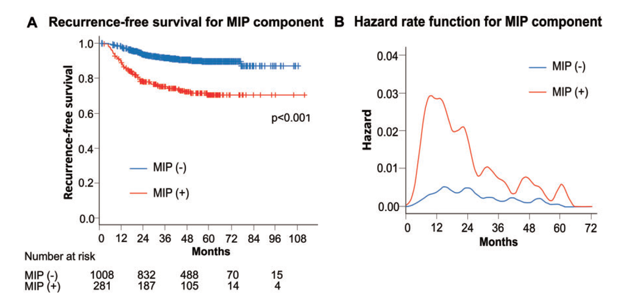

From https://pubmed.ncbi.nlm.nih.gov/32386405/

Figure 2: (A) Recurrence-free survival curves according to the presence of MIP component. (B) Smoothed hazard estimates for the presence of MIP component.

图B在例文中多次出现。 Figure B appears several times in the example.

## 3 应用场景 Application Scenarios

该图本质上就是一种核密度图。关于核密度图的基础知识可参考底部“附”。

例文应用风险曲线探索手术切除的肺腺癌微乳头这种组织学亚型术后不同时间内的复发风险。

我们用TCGA的pancancer临床信息做为输入数据，你可以顺利画出自己感兴趣的癌症的核密度图，展示某一特征随时间的变化。

这种图在更多文章中的应用：

- [Science. 2020;eabd2161.](https://pubmed.ncbi.nlm.nih.gov/32703910/)
- [Nature. 2012;486(7403):395-399. Fig.4C](https://pubmed.ncbi.nlm.nih.gov/22495314/);
- [Oncotarget. 2018;9(87):35742-35751.](https://pubmed.ncbi.nlm.nih.gov/30515266/)
- [JAMA Oncol. 2018;4(3):309-315.](https://pubmed.ncbi.nlm.nih.gov/29270608/)
- 本次复现的图参考[Neuro Oncol. 2015 Jul;17(7):999-1006.](https://pubmed.ncbi.nlm.nih.gov/25688120/)

This plot is fundamentally a kernel density plot. For foundational concepts of kernel density estimation, refer to the Appendix.

Example Use Case: The original study employed risk curves (a specialized kernel density visualization) to explore recurrence risks over time in the micropapillary histological subtype of resected lung adenocarcinoma.

Workflow Adaptation: Using the TCGA pan-cancer clinical data as input, you can generate kernel density plots for any cancer type of interest to visualize temporal changes in specific biological or clinical features.

Additional Literature Applications: For extended implementations of this visualization approach in peer-reviewed studies, see:

- [Science. 2020;eabd2161.](https://pubmed.ncbi.nlm.nih.gov/32703910/)
- [Nature. 2012;486(7403):395-399. Fig.4C](https://pubmed.ncbi.nlm.nih.gov/22495314/);
- [Oncotarget. 2018;9(87):35742-35751.](https://pubmed.ncbi.nlm.nih.gov/30515266/)
- [JAMA Oncol. 2018;4(3):309-315.](https://pubmed.ncbi.nlm.nih.gov/29270608/)
- Diagram reference for this reproduction: [Neuro Oncol. 2015 Jul;17(7):999-1006.](https://pubmed.ncbi.nlm.nih.gov/25688120/)

## 4 环境设置 Environment settings

```r
source("install_dependencies.R")
```

[output not shown]

```
## Scanning ttf files in /Library/Fonts/, /System/Library/Fonts, /System/Library/Fonts/Supplemental, ~/Library/Fonts/ ...
```

```
## Extracting .afm files from .ttf files...
```

[output not shown]

[output not shown]

```r
library(survival) # 生存分析 # Survival analysis
library(survminer)# 生存分析 # Survival analysis
library(openxlsx) # 读取数据 # Read the data
library(muhaz)    # 风险评估 # risk assessment
library(dplyr)    # 数据清洗 # Data cleansing
library(ggplot2)  # 绘图 # plot
library(cowplot)  # 拼图 # jigsaw puzzle

# 设置字体
# Set the font
# 施普林格·自然杂志社图片文字要求8号Helvetica or Arial，（https://www.nature.com/documents/aj-artworkguidelines.pdf）
# Springer Nature Magazine Picture text request No. 8 Helvetica or Arial,（https://www.nature.com/documents/aj-artworkguidelines.pdf）

# 对于HTML输出，使用系统字体，不需要extrafont
# For HTML output, use system fonts, no extrafont needed
font_available <- FALSE
default_font <- "Helvetica"
cat("使用系统默认字体:", default_font, " (HTML输出)\n")
```

```
## 使用系统默认字体: Helvetica  (HTML输出)
```

```r
Sys.setenv(LANGUAGE = "en") #显示英文报错信息 # error messages are displayed in English
options(stringsAsFactors = FALSE) #禁止chr转成factor # It is forbidden to convert chr into factor
```

## 5 输入文件的获得 Obtaining Input Files

如果你的数据已整理成`easy_input.csv`的格式，就跳过这步，直接进入“构建muhaz对象”。

input.xlsx，是TCGA最新的pancancer临床数据，出自[Cell. 2018;173(2):400-416.e11.](https://pubmed.ncbi.nlm.nih.gov/29625055/)的[补充材料](https://ars.els-cdn.com/content/image/1-s2.0-S0092867418302290-mmc1.xlsx)

后面将以性别gender作为分组举例子，实际分析时，把gender替换为你感兴趣的特征对应在panclin里的列名。或者把你经过其他分析获得的分类信息作为一列添加进去。

If your data is already formatted as easy_input.csv, skip this step and proceed directly to the Build muhaz Object section.

input.xlsx: Contains the latest TCGA pan-cancer clinical data sourced from the Supplementary Materials of the publication:[Cell. 2018;173(2):400-416.e11.](https://pubmed.ncbi.nlm.nih.gov/29625055/)[supplyment material](https://ars.els-cdn.com/content/image/1-s2.0-S0092867418302290-mmc1.xlsx)

Gender will be used as an example of grouping, and in the actual analysis, replace gender with the feature you are interested in corresponding to the list name in the panclin. Or add the classification information you’ve obtained through other analyses as a column.

```r
# 加载TCGA pancancer临床数据
# Load TCGA pancancer clinical data
panclin <- read.xlsx(xlsxFile = "input.xlsx",sheet = 1)
dim(panclin)
```

```
## [1] 11160    34
```

```r
panclin[1,] # 查看有哪些列 # See what columns there are
```

```
##   X1 bcr_patient_barcode type age_at_initial_pathologic_diagnosis gender  race
## 1  1        TCGA-OR-A5J1  ACC                                  58   MALE WHITE
##   ajcc_pathologic_tumor_stage   clinical_stage
## 1                    Stage II [Not Applicable]
##                      histological_type histological_grade
## 1 Adrenocortical carcinoma- Usual Type    [Not Available]
##   initial_pathologic_dx_year menopause_status birth_days_to vital_status
## 1                       2000  [Not Available]        -21496         Dead
##   tumor_status last_contact_days_to death_days_to  cause_of_death
## 1   WITH TUMOR                   NA          1355 [Not Available]
##   new_tumor_event_type new_tumor_event_site new_tumor_event_site_other
## 1   Distant Metastasis  Peritoneal Surfaces                       <NA>
##   new_tumor_event_dx_days_to treatment_outcome_first_course margin_status
## 1                        754    Complete Remission/Response          <NA>
##   residual_tumor OS OS.time DSS DSS.time DFI DFI.time PFI PFI.time Redaction
## 1           <NA>  1    1355   1     1355   1      754   1      754      <NA>
```

```r
# 选取感兴趣的癌症
# Select the cancer of interest
#panclin <- panclin[panclin$type %in% "ACC", ]

# 按例图的72个月调整生存数据
# Survival data were adjusted for 72 months as shown in the example figure
clin <- panclin %>%
  # 选取想要的列
  # Select the columns you want
  select(.,DFI, DFI.time,
         gender) %>% # 后面将以性别作为分组，选取gender列，可以替换为其他感兴趣的列名 # The gender column will be grouped later, and the gender column can be replaced with other column names of interest

  # 删除没有生存结局和时间的case # Delete cases that don't have a survival ending and time
  filter(!(is.na(.$DFI) | is.na(.$DFI.time))) %>%

  mutate(time_month = round(DFI.time/30,digits = 1)) %>%
  mutate(survevent = ifelse(DFI == 1 & time_month <= 72, 1, 0),
         survmonth = ifelse(time_month <=  72, time_month, 72))
dim(clin)
```

```
## [1] 5521    6
```

```r
# 保存到文件，便于套用
# Save to a file for easy application
write.csv(clin, "easy_input.csv", quote = F, row.names = F)
```

## 6 输入文件 Input files

easy_input.csv，包含生存信息，和一列分组信息（此处为gender）。 easy_input.csv，Contains survival information, and a column of grouping information (in this case, gender)

```r
clin <- read.csv("easy_input.csv")
head(clin)
```

```
##   DFI DFI.time gender time_month survevent survmonth
## 1   1      754   MALE       25.1         1      25.1
## 2   1       53 FEMALE        1.8         1       1.8
## 3   0     2703 FEMALE       90.1         0      72.0
## 4   1      530   MALE       17.7         1      17.7
## 5   1      414 FEMALE       13.8         1      13.8
## 6   0     3038 FEMALE      101.3         0      72.0
```

## 7 构建muhaz对象 Build the muhaz object

### 7.1 muhaz函数的参数设置 Parameter settings for the muhaz function

- times，生存时间向量
- delta，生存结局向量
- subset，如果不指定，表示将使用所有观察值
- min.time，max.time，设置分析时间区间段
- bw.pilot
  - 带宽bw值对应MISE（平均积分平方误差，mean intergrated squared error）最小化的bw值
  - 指定核密度估计的bw值，[默认根据Mueller and Wang (1994)的方法](https://pubmed.ncbi.nlm.nih.gov/8086616/)
  - 计算公式bw.pilot = (max.time - min.time)/(8 * nz^0.2)，其中nz删失的观察数
- bw.grid，对应MISE最小是的值，默认为以[0.2 * bw.pilot,20 * bw.pilot]为区间的21切分的bandwidth grid
- bw.smooth，用于设置平滑局部的带宽参数，如果bw.method=“global”，该参数无效，默认为5 * bw.pilot
- bw.method，算法设置，算法包括”global”,“local”(默认值)，“knn”，使用首字母即可
- b.cor，边界效应校正类型，“b”=“both”(表示校正双边的边界效应 )，“n”=“none”(默认值)，“l”=“left”，“r”=“right”
- n.min.grid,n.est.grid=101，前者默认51，后者默认101
- kern=“epanechnikov” 设置核函数，使用首字母即可，默认epanechnikov
- times: Vector of survival times.
- delta: Vector of event status indicators (0 = censored, 1 = event occurred).
- subset: Subset of observations to include. If unspecified, all observations are used.
- min.time, max.time: Define the time interval for analysis.
- bw.pilot:
  - Pilot bandwidth value minimizing the Mean Integrated Squared Error (MISE).
  - Default calculation follows the method by Mueller & Wang (1994).
  - Formula: bw.pilot = (max.time - min.time) / (8 * nz^0.2), where nz is the number of uncensored observations.
- bw.grid: Bandwidth grid for MISE minimization. Default: 21 equally spaced values between [0.2 * bw.pilot, 20 * bw.pilot].
- bw.smooth: Local smoothing bandwidth. Ignored if bw.method = “global”. Default: 5 * bw.pilot.
- bw.method: Algorithm for bandwidth selection:“global”: Global bandwidth.”local” (default): Locally adaptive bandwidth.”knn”: k-nearest neighbor-based bandwidth.(Abbreviations accepted, e.g., “g”, “l”, “k”).
- b.cor: Boundary correction type:“b” (both): Corrects left and right boundaries.”n” (default): No correction.”l”: Left boundary only.”r”: Right boundary only.
- n.min.grid: Minimum grid size. Default: 51. n.est.grid: Estimation grid size. Default: 101.
- kern: Kernel function. Options: “epanechnikov” (default). Other kernels may be specified by abbreviation (e.g., “e” for Epanechnikov).

### 7.2 构建muhaz对象 Build the muhaz object

```r
smoothhazp <- clin %>%
  group_by(gender) %>% #根据自己的需要修改分组列名 # Modify the group column names as needed
  do(haz = muhaz(times = .$survmonth,delta = .$survevent,
                 min.time = min(.$survmonth[.$survevent==1]),
                 max.time = max(.$survmonth[.$survevent==1]),
                 bw.grid = 7,bw.method = "g",b.cor = "b")) %>%
  do(data.frame(Hazard = .$haz$haz.est,
                Months = .$haz$est.grid,
                Subgroup = .$gender))
```

### 7.3 验证分析结果 Verify the results of the analysis

```r
# 检验一下
# Check it out
maxHaz <- smoothhazp %>% group_by(Subgroup) %>%
    summarise(stratMax=max(Hazard))
print(maxHaz)
```

```
## # A tibble: 2 × 2
##   Subgroup stratMax
##   <chr>       <dbl>
## 1 FEMALE    0.00988
## 2 MALE      0.00990
```

```r
# 估算HR
# Estimate HR
maxHaz$stratMax[2]/maxHaz$stratMax[1]
```

```
## [1] 1.001817
```

### 7.4 构建cox回归模型，对比一下 Build a COX regression model and compare it

```r
res.cox <- coxph(Surv(survmonth, survevent) ~ gender, data =  clin)
summary(res.cox)
```

```
## Call:
## coxph(formula = Surv(survmonth, survevent) ~ gender, data = clin)
##
##   n= 5521, number of events= 1079
##
##               coef exp(coef) se(coef)     z Pr(>|z|)
## genderMALE 0.13688   1.14669  0.06171 2.218   0.0266 *
## ---
## Signif. codes:  0 '***' 0.001 '**' 0.01 '*' 0.05 '.' 0.1 ' ' 1
##
##            exp(coef) exp(-coef) lower .95 upper .95
## genderMALE     1.147     0.8721     1.016     1.294
##
## Concordance= 0.523  (se = 0.008 )
## Likelihood ratio test= 4.88  on 1 df,   p=0.03
## Wald test            = 4.92  on 1 df,   p=0.03
## Score (logrank) test = 4.93  on 1 df,   p=0.03
```

## 8 开始画图 Start plotting

muhaz包自带plot.muhaz，这里我选择ggplot2来画图，分三步进行： The muhaz package comes with plot.muhaz, here I choose ggplot2 to draw the plot, in three steps:

### 8.1 先画风险曲线 Draw the risk curve first

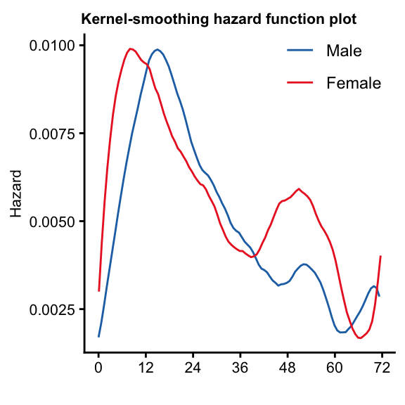

```r
# 自定义颜色
# Custom colors
orange <- "#EB292A"
blue <- "#2271B4"

p1 <- ggplot(smoothhazp, aes(x=Months, y=Hazard, colour= factor(Subgroup,labels = c("Male","Female")))) +
  geom_line() + ggtitle("Kernel-smoothing hazard function plot")+
  scale_color_manual(values = c(blue, orange)) +
  theme_classic() +
  theme(plot.title = element_text(hjust=-0.1, size=8, vjust=0.2, face = "bold"),
        axis.text = element_text(size=8, colour="black"),
        axis.title = element_text(size=8, colour="black"),
        legend.title = element_blank(),
        legend.position = c(0.8,0.9)) +
  scale_x_continuous(name = "", breaks = seq(0,72,12))

# 如果字体可用，应用字体设置
if (font_available) {
  p1 <- p1 + theme(text = element_text(family = default_font))
}

p1
```

这样就画出了例文那样的图。

下面是作者给出的升级版：加上风险表

This makes a diagram like the example text.

Here’s an upgraded version given by the author: plus the risk table

### 8.2 画风险表 Draw a risk table

这里我们使用survminer包的ggsurvplot构建风险表

Here we use the ggsurvplot of the survminer package to build the risk table

```
## Ignoring unknown labels:
## • colour : ""
```

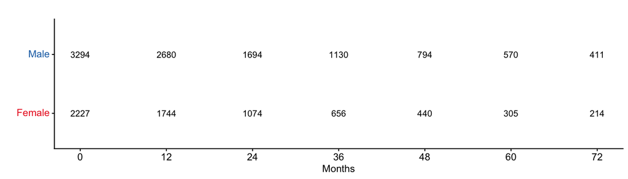

```r
fit <- survfit(Surv(survmonth, survevent) ~ gender, data = clin)

ggsurv <- ggsurvplot(fit, data = clin, risk.table = TRUE,
                     legend.title = "",                 # 设置图例标题 # Set the legend title
                     legend.labs = c("Male", "Female"), # 指定图例分组标签 # Specify the legend grouping label
                     palette = c(blue, orange),         #自定义颜色 # Custom colors

                     xlab = "Months",fontsize=2.5,      # 调节风险表字体大小 # Adjust the font size of the risk table
                     xlim = c(0,72), break.x.by = 12,
                     # 设置risk table xy轴及标签格式 # Set the risk table xy axis and label format
                     tables.theme = theme_survminer(base_size = 8,
                                                    #base_family = "Arial",
                                                    font.main = c(8, "plain", "black"),
                                                    font.x = c(8, "plain", "black"),
                                                    font.y = c(8, "plain", "black"),
                                                    font.tickslab = c(8, "plain", "black")))

p2 <- ggsurv$table +
  theme(legend.position = "none") + labs(title = "") # 删除风险表的title # Delete the title of the risk table
p2
```

### 8.3 组图 Combine plots

```
## Ignoring unknown labels:
## • colour : ""
```

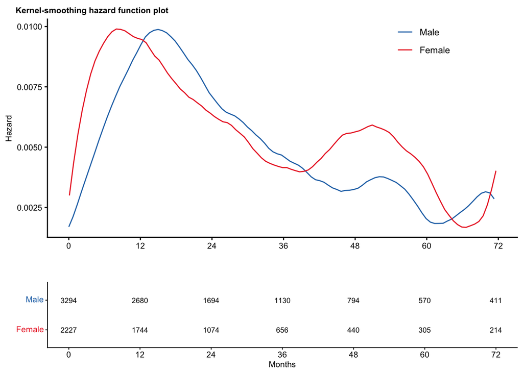

```r
# 组图
# merge plots
plot_grid(p1,p2,ncol=1,
          rel_heights = c(1,0.4),align = 'v')
```

```r
# 保存为pdf文件，是矢量图，可以用Illustrator等工具继续编辑
# Saved as a pdf file, it is a vector illustration that can be continued with tools such as Illustrator
pdf("smoothHaz.pdf", width = 3, height = 4)
plot_grid(p1,p2,ncol=1,
          rel_heights = c(1,0.4),align = 'v')
```

```
## Ignoring unknown labels:
## • colour : ""
```

```r
dev.off()
```

```r
# 或者保存为tiff
# Or save as a tiff
#ggsave(filename = "smoothHaz.tiff",width = 8,height = 8,units = 'cm',dpi = 300,compression='lzw')

# 或者导入ppt继续编辑
# Or import PPT to continue editing
#export::graph2ppt(file = "smoothHaz.pptx",width = 3,height = 4)
```

## 9 附 Appendix

[核密度估计](https://en.wikipedia.org/wiki/Kernel_density_estimation)：一种非参数估计方法,根据已知的抽样数据推算总体概率分布的过程。

[核Kernel](https://en.wikipedia.org/wiki/Kernel_density_estimation)，表示核函数，常见的核函数如高斯函数（正态分布）。

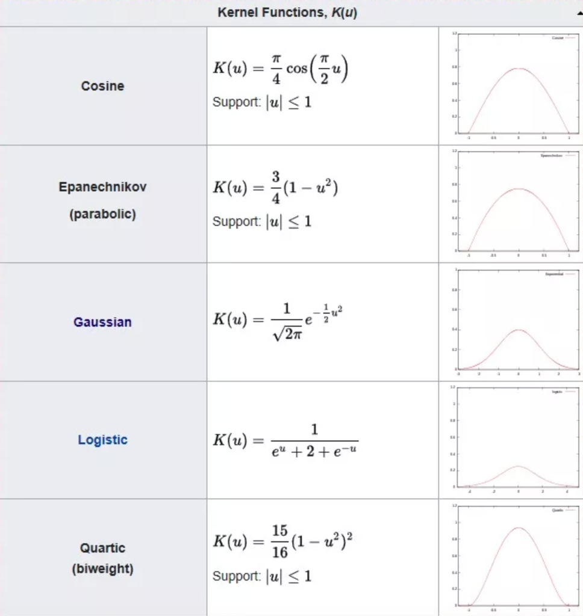

Kernel Density Estimation (KDE): A non-parametric method to estimate the probability density function of a population based on observed sample data.(https://en.wikipedia.org/wiki/Kernel_density_estimation)

Kernel Function: Defines the shape of the weighting function used in KDE. Common kernels include the Gaussian kernel (normal distribution) and Epanechnikov kernel.(https://en.wikipedia.org/wiki/Kernel_density_estimation)

上图摘自[基迪奥生物](https://mp.weixin.qq.com/s/Kkc7kNUaUl0nU0Y8EQoMbA)

[带宽 bandwidth](https://en.wikipedia.org/wiki/Kernel_density_estimation)是一个自由参数，可以调节核密度估计曲线的平滑度，核的带宽越大曲线越平滑

The image above is taken from[基迪奥生物](https://mp.weixin.qq.com/s/Kkc7kNUaUl0nU0Y8EQoMbA)

[bandwidth](https://en.wikipedia.org/wiki/Kernel_density_estimation)is a free parameter that adjusts the smoothness of the kernel density estimation curve, and the larger the bandwidth of the core, the smoother the curve